# Momentum Time Series

LT 9 12 2021

**Momentum of S&P500 Tech Stocks**

This notebook applies time series analysis to momentum of S&P Tech Index. Stock momentum is calculated over three-month period, and can be read as what three-month return would generate investment of $100 in S&P Tech Index over time? S&P Tech Index could be approximated with SPDR Technology ETF price, which resembles S&P500 Tech, however, my preference was to use equal-weighted index while S&P500 is market-cap weighted.

Idea behind this project is derived from momentum investment philosophy, i.e. investing in assets that have been increasing in value recently, and closing position in assets that have been decreasing. I am going to utilize ARIMA (Autoregressive Integrated Moving Average) model for this problem. In simplification, Autoregressive compontent of ARIMA model measures impact of previous time series values on today’s value, while Moving Average part measures impact of previous shocks in series on today’s value. Estimated parameters should help in answering the question if momentum indeed is present in the data. If AR parameters were positive and statistically significant, it would imply that past values explain today’s time series value.

In conclusion of this analysis I would like to specify if ARIMA appropriately explains this particular momentum dataset, what are p,d,q values of ARIMA model, and what’s the predictive ability of the most appropriate model defined. Potentially, I would like to improve predictive ability by employing GARCH model to residuals, given that financial time series frequently exhibit conditional hetoreskadisticity, which in simpler terms can be described as volatility clustering - periods of low volatility followed by clusters of higher volatile periods.

This analysis should help in forming investment strategy on Tech Index that would outperform simple buy-and-hold strategy.

**Libraries & Dataset**

Libraries used for this analysis are forecast, tibble, fpp2, rugarch, tseries & ggplot2, plotly for visualizations.

```r
library(forecast)
library(tibble)
library(fpp2)
library(rugarch)
library(urca)
library(ggplot2)
library(plotly)
```

Dataset was compiled in Python (my preferred language for data extraction & manipulation), and the output was loaded to R. First, prices for all S&P500 Tech Stocks (latest available composition) were extracted from Yahoo Finance and daily growth rates were computed for each stock. Then, for each day, growth rates were averaged so that the output would be simple (or equal-weighted) average daily return for the whole index. For each day, missing observations were excluded - these were growth rates for stocks that were IPOed later in the analysis period. Then, assuming that $100 was the beginnig value of the index, each next day’s index value was calculated by multiplying said $100 by average daily growth rate for the sector. This formed the time series of Tech Stock Index and subsequently it was utilized to calculate three-month momentum series. Momentum series starts at 2014-01-02, and can be interpreted as what return would be generated in 3 months if $100 was invested at day 2014-01-02, and this question rolls forward throughout the whole time frame. First couple of observations are provided below, accompanied with a graphical representation of the dataset.

```
##          Date Momentum
## 1  2014-01-02 108.7291
## 2  2014-01-03 107.6629
## 3  2014-01-06 105.7630
## 4  2014-01-07 103.5651
## 5  2014-01-08 104.0389
## 6  2014-01-09 105.8027
## 7  2014-01-10 102.0736
## 8  2014-01-13 101.6562
## 9  2014-01-14 100.7477
## 10 2014-01-15  99.7799
```

[interactive chart not shown]

Analysis of Stationarity In The Data

At the first glance, momentum data look stationary: there seem to be a constant long-term mean at around 106, and constant variance over time with a few significant spikes, like ones at November 2018 & January 2020. If one invested at these dates, then their return from investment would drop down as far as c25%.

Stationarity is a crucial concept as many statistical methods are based on this assumption, i.e. statistical properties of a time series are constant over time. For these models, if stationarity condition is not satisfied, then estimates and statistical inferrence is unreliable and might be misleading.

Different methods can be employed to conclude about stationarity. First, plotting the data and looking at the ACF/PACF (Autocorrelation Function) plots. Another option is to perform parametric tests like Augmented Dickey-Fuller or KPSS tests. Code and results are presented below.

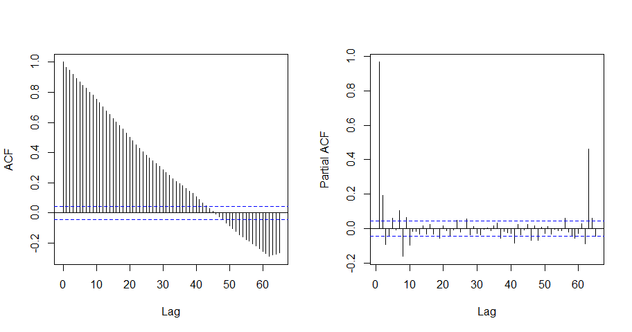

```r
par(mfrow=c(1,2))
acf(data$Momentum, lag = 65, main = NA)
pacf(data$Momentum, lag = 65, main = NA)
```

ADF test hypothesis set:  
H0: unit root is present in a time series  
H1: root outside the unit circle, which is usually equivalent to stationary or trend stationary.  
Wikipedia’s definition on unit root states that linear stochastic process has a unit root if 1 is a root of the process’s characteristic equation. Less formally though, if a process has unit root, then shock affecting time series should disappear with time.

```r
library(tseries)
adf_test = adf.test(data$Momentum)
adf_test
```

```
##
##  Augmented Dickey-Fuller Test
##
## data:  data$Momentum
## Dickey-Fuller = -5.5673, Lag order = 12, p-value = 0.01
## alternative hypothesis: stationary
```

KPSS test hypothesis set:  
H0: data is (trend) stationary  
H1: unit root is present in a time series

```r
library(tseries)
kpss_test = kpss.test(data$Momentum)
kpss_test
```

```
##
##  KPSS Test for Level Stationarity
##
## data:  data$Momentum
## KPSS Level = 1.0568, Truncation lag parameter = 8, p-value = 0.01
```

Result of ADF test is p-value below significance level of 0.05, hence null hypothesis can be rejected in favor of alternative hypothesis: root is outside the unit circle, data should be stationary.

Result of KPSS test is p-value below significance level of 0.05, hence null hypothesis can be rejected in favor of alternative hypothesis: unit root is present in time series.

Above tests provide spurious results, where ADF suggest that data is stationary and KPSS says the opposite. Such a contradiction might happen with series that are stationary by difference, meaning that differencing the series D times should transform it to a realization of stationary process. In other words, it can be said that time series are *integrated processes* when they can be made stationary by differencing. Let’s do that next, visualize the differenced series and again plot the ACF and compute ADF & KPSS tests.

```r
# Add columnt with differenced momentum values

data["MomentumDiff"] = rep(NA,1912)
data[2:1912,"MomentumDiff"] = diff(data$Momentum)
data = na.omit(data)
head(data,10)
```

```
##          Date Momentum MomentumDiff
## 2  2014-01-03 107.6629   -1.0661309
## 3  2014-01-06 105.7630   -1.8998994
## 4  2014-01-07 103.5651   -2.1979296
## 5  2014-01-08 104.0389    0.4738079
## 6  2014-01-09 105.8027    1.7638222
## 7  2014-01-10 102.0736   -3.7291795
## 8  2014-01-13 101.6562   -0.4173381
## 9  2014-01-14 100.7477   -0.9085427
## 10 2014-01-15  99.7799   -0.9677795
## 11 2014-01-16 101.0200    1.2400859
```

[interactive chart not shown]

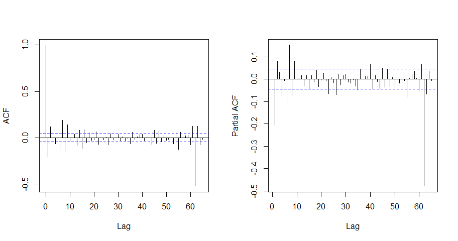

```
##
##  Augmented Dickey-Fuller Test
##
## data:  data$MomentumDiff
## Dickey-Fuller = -11.902, Lag order = 12, p-value = 0.01
## alternative hypothesis: stationary

##
##  KPSS Test for Level Stationarity
##
## data:  data$MomentumDiff
## KPSS Level = 0.01193, Truncation lag parameter = 8, p-value = 0.1
```

After differencing the series one time ACF plot suggest non-stationarity has been removed successfully. There are still some significant spikes, especially for lags up to 10, however, the steady decay pattern has been successfully removed. What about ADF and KPSS test? ADF’s p-value is 0.01, hence we can remove null hypothesis in favor of alternative saying that data should be (trend) stationary; KPSS’s p-value is 0.1, so above significance level of 0.05, hence we cannot reject the null hypothesis of (trend) stationarity of the data. Three diagnostics utilized points toward same conclusion: momentum data is an integrated process of order 1, to transform it to stationarity differencing needs to be applied.

Differenced series will be used for further analysis.

**Finding Best ARIMA Fit**

Let’s first check what model auto.arima function propose for the data we have.

```r
library(forecast)
data_diff = ts(data$MomentumDiff, start = 1, frequency = 62)
fit = auto.arima(data_diff)
summary(fit)
```

```
## Series: data_diff
## ARIMA(4,0,5)(1,0,0)[62] with zero mean
##
## Coefficients:
##           ar1     ar2      ar3      ar4     ma1      ma2     ma3     ma4
##       -0.5411  0.4470  -0.2620  -0.6773  0.4077  -0.4371  0.3712  0.5126
## s.e.   0.1167  0.1636   0.1429   0.0815  0.1178   0.1589  0.1386  0.0798
##           ma5     sar1
##       -0.0833  -0.5131
## s.e.   0.0304   0.0194
##
## sigma^2 estimated as 3.229:  log likelihood=-3836.4
## AIC=7694.79   AICc=7694.93   BIC=7755.9
##
## Training set error measures:
##                        ME     RMSE      MAE      MPE     MAPE      MASE
## Training set -0.002661188 1.792365 1.299684 119.2869 341.5632 0.4830803
##                     ACF1
## Training set 0.001131685
```

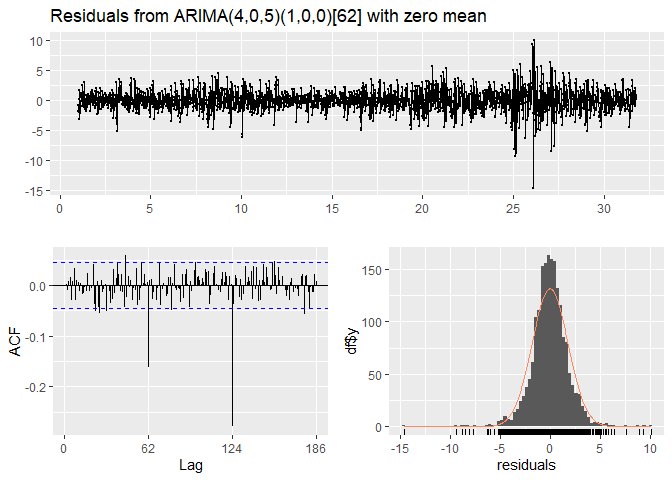

```
##
##  Ljung-Box test
##
## data:  Residuals from ARIMA(4,0,5)(1,0,0)[62] with zero mean
## Q* = 349, df = 114, p-value < 2.2e-16
##
## Model df: 10.   Total lags used: 124
```

```r
checkresiduals(fit)
```

Function auto.arima has fitted ARIMA model of order p = 4, d = 0, q = 5 and seasonal components P = 1, D = 0, Q = 0 for data with frequency 62 as the most preferred fit. Hence, today’s value for differenced series is impacted by AR(4) and MA(5) components, and AR(1)[62] component. It can be understood that today’s value is influenced by 4 latest values, one value from 62 days before and last 5 errors (shocks).

When we inspect residuals diagnostics produced by checkresiduals function, then we can notice significant ACF spikes at regular lags of k*62. It means that perhaps seasonality component was not captured properly. It would be desirable to improve that so that errors do not incorporate any information that could be captured by the model itself. Moreover, distribution of residuals is not normal, but rather negatively skewed, but this cannot always be remedied. Let’s try to adjust seasonal component of the proposed ARIMA model first so that residuals become random indeed. First idea is to change seasonal component from (1,0,0) to (0,0,1).

```r
library(forecast)
fit2 = Arima(data_diff, order = c(4,0,5), seasonal = list(order = c(0,0,1)))
summary(fit2)
```

```
## Series: data_diff
## ARIMA(4,0,5)(0,0,1)[62] with non-zero mean
##
## Coefficients:
##           ar1     ar2      ar3      ar4     ma1      ma2     ma3     ma4
##       -0.5561  0.4844  -0.1633  -0.6296  0.4052  -0.4673  0.2874  0.4613
## s.e.   0.1658  0.2188   0.1395   0.0910  0.1657   0.2047  0.1328  0.0817
##           ma5     sma1    mean
##       -0.0856  -0.7736  0.0019
## s.e.   0.0301   0.0172  0.0082
##
## sigma^2 estimated as 2.666:  log likelihood=-3671.62
## AIC=7367.24   AICc=7367.4   BIC=7433.9
##
## Training set error measures:
##                        ME     RMSE     MAE      MPE     MAPE    MASE
## Training set -0.005057508 1.628177 1.15892 100.4258 289.0711 0.43076
##                      ACF1
## Training set 0.0009639271
```

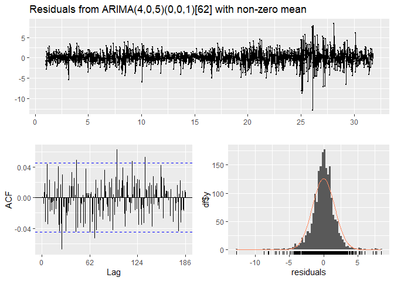

```
##
##  Ljung-Box test
##
## data:  Residuals from ARIMA(4,0,5)(0,0,1)[62] with non-zero mean
## Q* = 142.8, df = 113, p-value = 0.03045
##
## Model df: 11.   Total lags used: 124
```

```r
checkresiduals(fit2)
```

Apparently, it worked. Significant spikes at ACF plot are no more visible, and goodness of fit measures imrpoved as well - they are lower for ARIMA(4,0,5)(0,0,1) than ARIMA(4,0,5)(1,0,0).

There is still chance that we can improve the model even further by looking at different orders of p & q, therefore let’s try to perform grid search on parameters p & q up to 10. Let’s assume that parameter d is 0 now, given that we previously differenced the series and removed the integration of the process (the I in ARIMA model). At this point the interest goes towards model minimizing AIC/BIC/AICC as well as LjungBox test that verifies (lack of) serial autocorrelation in residuals.

```r
library(tibble)
params = tibble("A", 0,1,2,"Lb") # tibble named so that each column has appropriate type (character/double)
colnames(params) = c("Order", "AIC","BIC","AICC","LjungBox20")
i = 0
for(p in (0:10)){
  for(d in (0)){
    for(q in (0:10)){
      print(paste("Working on", p, d, q, sep =" "))

      modelest = try(Arima(data_diff, order = c(p,d,q),
                       seasonal = list(order = c(0,0,1))))

      if(class(modelest)[1] != "try-error"){
        LjungBox = Box.test(as.vector(na.omit(modelest$residuals)),
                         type = c("Ljung-Box"), lag = 20)

        i = i + 1
        params[i, "Order"] = paste(p, d, q, sep =",")
        params[i, "AIC"] = modelest$aic
        params[i, "BIC"] = modelest$bic
        params[i, "AICC"] = modelest$aicc
        params[i, "LjungBox20"] = sprintf("%.5f",LjungBox$p.value)
      }else{
        i = i + 1
        params[i, "Order"] = "NA"
        params[i, "AIC"] = 99999
        params[i, "BIC"] = 99999
        params[i, "AICC"] = 99999
        params[i, "LjungBox20"] = "NA"
      }
    }
  }
}
```

```
## # A tibble: 10 x 5
##    Order    AIC   BIC  AICC LjungBox20
##    <chr>  <dbl> <dbl> <dbl> <chr>
##  1 3,0,9  7358. 7442. 7359. 0.99618
##  2 9,0,9  7360. 7476. 7360. 0.98857
##  3 7,0,9  7360. 7465. 7360. 0.98986
##  4 8,0,8  7360. 7465. 7360. 0.98865
##  5 3,0,10 7360. 7449. 7361. 0.99268
##  6 6,0,6  7360. 7444. 7361. 0.99083
##  7 9,0,7  7361. 7466. 7361. 0.99976
##  8 6,0,2  7361. 7422. 7361. 0.99935
##  9 7,0,2  7361. 7428. 7362. 0.99773
## 10 8,0,4  7361. 7445. 7362. 0.99941
```

From the output above it can be stated that w.r.t AIC/AICC measures best model is of order ARIMA(3,0,9)(0,0,1). AIC and AICC are preferred as their objective is forecasting accuracy.

**Time Series Cross Validation**

Best model selection has been performed on the whole dataset, while a common practice is to split the data into training set and test set, where the model can be fit with the first set and then it’s predictive ability tested with the second set. Because the test data is not used in determining the model, it should provide a reliable indication of how well the model is likely to forecast on new data. Usually split is done 70/30 or 80/20, for the training and test sets respectively. However, this one arbitrary split may lead to a selection bias, where the training set is not representative of the true distribution, hence the model itself won’t be able to predict correctly.

Therefore, a bit more sophisticated version of train/test split can be applied as a potential remady, that is time series cross validation. In this procedure, there are a series of test sets, each consisting of a single observation. The corresponding training set consists only of observations that occurred prior to the observation that forms the test set. Forecast errors are commonly summarized with RMSE metric (Root Mean Squared Error).

```r
rolling_tscv<-function(y, nobs, steps = 1, fcast = 1, p, d, q){
  # numeric to store RMSE:
  output = 0

  # number of iterations to be performed based on parameters provided
  len = length(y)
  iterations = floor((len - fcast - nobs)/steps)+1

  print(paste("Model ", p,d,q, "Total iterations: ", iterations, seq = ""))

  # train Arima model of selected order(p,d,q) on first number of observations (nobs)
  yfit = ts(y[0:nobs],frequency = 62)
  model_train = Arima(yfit, order = c(p,d,q), seasonal = list(order = c(0,0,1)),
                      include.mean = FALSE)

  # perform iterations
  if((len - fcast) > nobs){
    for(i in seq(iterations)){
      step = (i-1)*steps
      ytrain = ts(y[step:(nobs + step)], frequency = 62) # create new training set
      ytest = y[(nobs+step+fcast)] # create new test set
      modfit = Arima(ytrain, model = model_train) # fit model with parameters   estimated in model_train
      fcastv = forecast(modfit, h = fcast) # forecast h-steps forward
      fcastv = fcastv$mean[fcast] # extract forecast h
      errorsq = (fcastv - ytest)^2 # compute squared error
      output = output + errorsq # sum of squared errors
    }
  }
  rmse = sqrt(output/iterations) # root mean of squared erros
  return(rmse)
}
```

```r
m = matrix(0, nrow = 11^2, ncol = 2) # p and q from 0 to 10, hence nrwos = 11^2
rmse_output = data.frame(m)
colnames(rmse_output) = c("Order", "RMSE")
rmse_output$Order = orders # orders is a vector of all orders from ARIMA grid search

# For each model
for(i in 1:dim(rmse_output)[1]){
  order = unlist(strsplit(rmse_output$Order[i], ","))
  p = as.numeric(order[1])
  d = as.numeric(order[2])
  q = as.numeric(order[3])

  rmse_output[i,2] = rolling_tscv(data_diff, nobs = 1260, steps = 6, fcast = 5, p, d, q)
}
```

```
##      Order     RMSE
## 62   5,0,6 2.229675
## 59   5,0,3 2.233378
## 60   5,0,4 2.234063
## 118 10,0,7 2.236516
## 80   7,0,2 2.243411
## 68   6,0,1 2.245440
## 63   5,0,7 2.247926
## 89   8,0,0 2.249028
## 83   7,0,5 2.249401
## 52   4,0,7 2.249911
```

```r
rolling_tscv(data_diff, nobs = 1260, steps = 6, fcast = 5, 5, 1, 6)
```

```
## [1] "Model  5 1 6 Total iterations:  108 "

## [1] 2.232297
```

```r
rolling_tscv(data_diff, nobs = 1260, steps = 6, fcast = 5, 3, 1, 9)
```

```
## [1] "Model  3 1 9 Total iterations:  108 "

## [1] 2.27912
```

**Forecasting**

For the selected model, let’s forecast and plot the estimates vs. actually observed values.

```r
generate_fcasts<-function(y, nobs, steps = 1, fcast = 1, p, d, q){
  output = as.double()

  len = length(y)
  iterations = floor((len - fcast - nobs)/steps)+1
  print(paste("Model ", p,d,q, "Total iterations: ", iterations, seq = ""))
  yfit = ts(y[0:nobs],frequency = 62)
  model_train = Arima(yfit, order = c(p,d,q), seasonal = list(order = c(0,0,1)))

  if((len - fcast) > nobs){
    for(i in seq(iterations)){
      step = (i-1)*steps
      ytrain = ts(y[step:(nobs + step)], frequency = 62)
      ytest = y[(nobs+step+fcast)]
      modfit = Arima(ytrain, model = model_train)
      fcastv = forecast(modfit, h = fcast)
      fcastv = fcastv$mean[fcast]
      output[i] = fcastv
    }
  }
  return(output)
}
```

```r
momentum = ts(data$Momentum, start = 1, frequency = 62)
fcast = generate_fcasts(momentum, nobs = 1260, steps = 1, fcast = 5, p=5, d=1, q=6)
```

```
## [1] "Model  5 1 6 Total iterations:  647 "
```

```r
fcast_df = data.frame("Date"=data$Date[1265:1911])
fcast_df["Forecast"] = fcast
fcast_df["Actual"] = data$Momentum[1265:1911]
head(fcast_df)
```

```
##         Date Forecast   Actual
## 1 2019-01-11 123.8077 123.1842
## 2 2019-01-14 126.0329 125.6379
## 3 2019-01-15 124.3749 124.1035
## 4 2019-01-16 123.4277 125.0889
## 5 2019-01-17 123.8893 123.8243
## 6 2019-01-18 121.7868 121.5484
```

[interactive chart not shown]

Attempt to Augment Forecasting Capability With Volatility Modelling

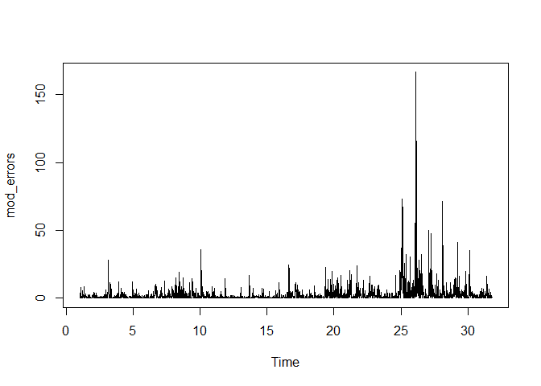

```r
library(forecast)
momentum = ts(data$Momentum, start = 1, frequency = 62)
modelfit = Arima(momentum, order = c(5,1,6), seasonal = list(order = c(0,0,1)))
mod_errors = modelfit$residuals^2
plot(mod_errors)
```

```r
library(rugarch)
vol = mod_errors
ug_spec = ugarchspec(mean.model = list(armaOrder = c(0,0)),
                     variance.model = list(model = "sGARCH", garchOrder = c(1,1)))
ugfit = ugarchfit(spec = ug_spec, data = vol)
ugfit
```

```
##
## *---------------------------------*
## *          GARCH Model Fit        *
## *---------------------------------*
##
## Conditional Variance Dynamics
## -----------------------------------
## GARCH Model  : sGARCH(1,1)
## Mean Model   : ARFIMA(0,0,0)
## Distribution : norm
##
## Optimal Parameters
## ------------------------------------
##         Estimate  Std. Error  t value Pr(>|t|)
## mu        1.3136    0.072693  18.0701        0
## omega     1.5608    0.274906   5.6776        0
## alpha1    0.2780    0.021241  13.0881        0
## beta1     0.7210    0.025626  28.1357        0
##
## Robust Standard Errors:
##         Estimate  Std. Error  t value Pr(>|t|)
## mu        1.3136     0.18307  7.17542 0.000000
## omega     1.5608     2.20992  0.70627 0.480024
## alpha1    0.2780     0.12371  2.24718 0.024629
## beta1     0.7210     0.21022  3.42969 0.000604
##
## LogLikelihood : -5412.225
##
## Information Criteria
## ------------------------------------
##
## Akaike       5.6685
## Bayes        5.6801
## Shibata      5.6685
## Hannan-Quinn 5.6728
##
## Weighted Ljung-Box Test on Standardized Residuals
## ------------------------------------
##                         statistic   p-value
## Lag[1]                      19.46 1.025e-05
```

[output cut: 37 more lines]

```
## Negative Sign Bias  0.7380 0.4606
## Positive Sign Bias  0.1245 0.9010
## Joint Effect        3.6328 0.3039
##
##
## Adjusted Pearson Goodness-of-Fit Test:
## ------------------------------------
##   group statistic p-value(g-1)
## 1    20      2707            0
## 2    30      2728            0
## 3    40      2791            0
## 4    50      2833            0
##
##
## Elapsed time : 0.1586339
```

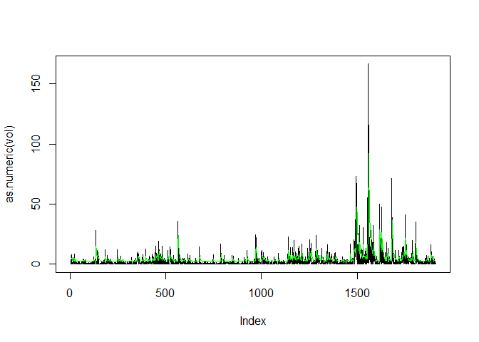

```r
plot(as.numeric(vol), type = "l")
lines(sqrt(ugfit@fit$var), col = "green")
```

```
##
## please wait...calculating quantiles...
```

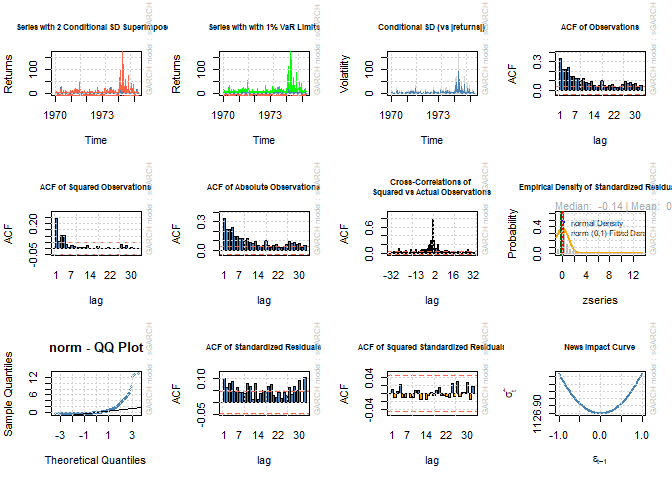

```r
plot(ugfit, which = "all")
```

```r
generate_vol_fcasts<-function(y, nobs, steps = 1, fcast = 1){
  output = as.double()

  len = length(y)
  iterations = floor((len - fcast - nobs)/steps)+1
  print(paste("Total iterations: ", iterations, seq = ""))
  yfit = ts(y[0:nobs],frequency = 62)

  # SARIMA
  model_train = Arima(yfit, order = c(5,1,6), seasonal = list(order = c(0,0,1)))

  # GARCH
  ugspec = ugarchspec(mean.model = list(armaOrder = c(0,0)),
                     variance.model = list(model = "sGARCH", garchOrder = c(1,1)))
  # Iterations
  if((len - fcast) > nobs){
    for(i in seq(iterations)){
      step = (i-1)*steps
      # Train/Test Split
      ytrain = ts(y[step:(nobs + step)], frequency = 62)

      # Fit ARIMA & forecast
      modfit = Arima(ytrain, model = model_train)
      fcast_arima = forecast(modfit, h = fcast)
      fcast_arima = fcast_arima$mean[fcast]

      # Fit GARCH & forecast
      resid = modfit$residuals^2
      ugfit = ugarchfit(spec = ugspec, data = resid)
      fcast_garch = ugarchforecast(fitORspec = ugfit, n.ahead = 5)
      fcast_garch = fcast_garch@forecast$sigmaFor[5]*mean(rnorm(1000)) # standard deviation

      output[i] = fcast_arima + fcast_garch
    }
  }
  return(output)
}
```

```r
momentum = ts(data$Momentum, start = 1, frequency = 62)
fcast = generate_vol_fcasts(momentum, nobs = 1260, steps = 1, fcast = 5)
```

```
## [1] "Total iterations:  647 "
```

```r
fcast_df = data.frame("Date"=data$Date[1265:1911])
fcast_df["Forecast"] = fcast
fcast_df["Actual"] = data$Momentum[1265:1911]
head(fcast_df)
```

```
##         Date Forecast   Actual
## 1 2019-01-11 123.3852 123.1842
## 2 2019-01-14 126.1793 125.6379
## 3 2019-01-15 124.5860 124.1035
## 4 2019-01-16 123.3218 125.0889
## 5 2019-01-17 123.7496 123.8243
## 6 2019-01-18 121.7675 121.5484
```

[interactive chart not shown]

```r
rolling_vol_tscv<-function(y, nobs, steps = 1, fcast = 1){
  # numeric to store RMSE:
  output = 0

  # number of iterations to be performed based on parameters provided
  len = length(y)
  iterations = floor((len - fcast - nobs)/steps)+1

  print(paste("Total iterations: ", iterations, seq = ""))

  # train Arima model of selected order(p,d,q) on first number of observations (nobs)
  yfit = ts(y[0:nobs],frequency = 62)
  model_train = Arima(yfit, order = c(5,1,6), seasonal = list(order = c(0,0,1)),
                      include.mean = FALSE)

  # GARCH
  ugspec = ugarchspec(mean.model = list(armaOrder = c(0,0)),
                     variance.model = list(model = "sGARCH", garchOrder = c(1,1)))

  # perform iterations
  if((len - fcast) > nobs){
    for(i in seq(iterations)){
      step = (i-1)*steps
      ytrain = ts(y[step:(nobs + step)], frequency = 62) # create new training set
      ytest = y[(nobs+step+fcast)] # create new test set

      # Fit ARIMA & forecast
      modfit = Arima(ytrain, model = model_train)
      fcast_arima = forecast(modfit, h = fcast)
      fcast_arima = fcast_arima$mean[fcast]

      # Fit GARCH & forecast
      resid = modfit$residuals^2
      ugfit = ugarchfit(spec = ugspec, data = resid)
      fcast_garch = ugarchforecast(fitORspec = ugfit, n.ahead = 5)
      fcast_garch = fcast_garch@forecast$sigmaFor[5] # standard deviation

      errorsq = ((fcast_arima+fcast_garch*mean(rnorm(1000))) - ytest)^2 # compute squared error
      output = output + errorsq # sum of squared errors
    }
  }
  rmse = sqrt(output/iterations) # root mean of squared erros
  return(rmse)
}
```

```r
rolling_vol_tscv(momentum, nobs = 1260, steps = 1, fcast = 5)
```

```
## [1] "Total iterations:  647 "

## [1] 4.647124
```

```r
rolling_tscv(momentum, nobs = 1260, steps = 1, fcast = 5, p=5, d=1, q=6)
```

```
## [1] "Model  5 1 6 Total iterations:  647 "

## [1] 4.619513
```

Addition of GARCH model to residuals doesn’t improve performance of ARIMA. Therefore, the choice is ARIMA(5,1,6)(0,0,1)

**Generating Buy & Sell Signals for Momentum Strategy**

Plot tech index over analysis window.

```r
path2 = "C:/Users/lukas/projects_py/Stock Market/files/techindex.csv"
tech_index = read.csv(path2)
tech_index = tech_index[,c("Date","Technology")]
tech_index[,'Date'] = as.Date(tech_index$Date)
#tech_index[,'Technology'] = log(tech_index$Technology)
head(tech_index,10)
```

```
##          Date Technology
## 1  2014-04-02   108.7291
## 2  2014-04-03   107.8342
## 3  2014-04-04   105.4559
## 4  2014-04-07   104.3362
## 5  2014-04-08   105.2322
## 6  2014-04-09   106.7476
## 7  2014-04-10   103.5396
## 8  2014-04-11   102.1264
## 9  2014-04-14   103.1032
## 10 2014-04-15   103.6469
```

Add MACD

```r
library(pracma)
Tech_MA12 = movavg(tech_index$Technology,n=5, type = "e")
Tech_MA26 = movavg(tech_index$Technology,n=26, type = "e")
tech_index["Tech_MA12"] = Tech_MA12
tech_index["Tech_MA26"] = Tech_MA26
head(tech_index)
```

```
##         Date Technology Tech_MA12 Tech_MA26
## 1 2014-04-02   108.7291  108.7291  108.7291
## 2 2014-04-03   107.8342  108.4308  108.6628
## 3 2014-04-04   105.4559  107.4391  108.4252
## 4 2014-04-07   104.3362  106.4048  108.1223
## 5 2014-04-08   105.2322  106.0140  107.9083
## 6 2014-04-09   106.7476  106.2585  107.8223
```

```r
library(plotly)
p <- ggplot(tech_index, aes(x=Date, y = Technology, group = 1)) +
  geom_line(color = '#FAF2CC', size = 0.3) +
  xlab("")+
  ylab("Tech Index")
p <- p + scale_x_date(date_labels = "%m/%Y", date_breaks = "3 month") +
  theme(panel.background = element_rect(fill = "#06314F"),
        panel.grid.major = element_blank(),
        panel.grid.minor = element_blank()) +
  theme(axis.text.x = element_text(angle=45, hjust =1))

ggplotly(p, size=2)
```

[interactive chart not shown]

```r
library(pracma)
data
```

```
##            Date  Momentum  MomentumDiff
## 2    2014-01-03 107.66294 -1.066131e+00
## 3    2014-01-06 105.76304 -1.899899e+00
## 4    2014-01-07 103.56511 -2.197930e+00
## 5    2014-01-08 104.03892  4.738079e-01
## 6    2014-01-09 105.80274  1.763822e+00
## 7    2014-01-10 102.07356 -3.729180e+00
## 8    2014-01-13 101.65622 -4.173381e-01
## 9    2014-01-14 100.74768 -9.085427e-01
## 10   2014-01-15  99.77990 -9.677795e-01
## 11   2014-01-16 101.01999  1.240086e+00
## 12   2014-01-17 101.93434  9.143519e-01
## 13   2014-01-21 102.19668  2.623417e-01
## 14   2014-01-22 102.81040  6.137144e-01
## 15   2014-01-23 102.90111  9.071603e-02
```

[output cut: 1897 more lines]

```r
Momentum_MA12 = movavg(data$Momentum,n=6, type = "e")
Momentum_MA26 = movavg(data$Momentum,n=12 , type = "e")
data[,"Date"] = tech_index$Date[2:1912]
data["Momentum_MA12"] = Momentum_MA12
data["Momentum_MA26"] = Momentum_MA26
data["Con_Div"] = data$Momentum-data$Momentum_MA26
row.names(data) = NULL #reset index
head(data)
```

```
##         Date Momentum MomentumDiff Momentum_MA12 Momentum_MA26    Con_Div
## 1 2014-04-03 107.6629   -1.0661309      107.6629      107.6629  0.0000000
## 2 2014-04-04 105.7630   -1.8998994      107.1201      107.3706 -1.6076071
## 3 2014-04-07 103.5651   -2.1979296      106.1044      106.7852 -3.2200695
## 4 2014-04-08 104.0389    0.4738079      105.5143      106.3627 -2.3237598
## 5 2014-04-09 105.8027    1.7638222      105.5967      106.2765 -0.4737934
## 6 2014-04-10 102.0736   -3.7291795      104.5901      105.6299 -3.5563617
```

```r
treshold = log(96.5)

p <- ggplot(data, aes(x=Date, y = log(Momentum), group = 1)) +
  geom_line(color = '#FAF2CC', size = 0.3, lty = 1) +
  geom_line(aes(x=Date, y = treshold), color = "grey") +
  geom_line(aes(x=Date, y = log(Momentum_MA26)), color = "yellow") +
  geom_line(aes(x=Date, y = log(Momentum_MA12)), color = "yellow", lty = 2) +
  #geom_col(aes(x=Date, y = log(Momentum_MA12)-log(Momentum_MA26)), lty = 2 ) +
  xlab("")+
  ylab("Momentum")
p <- p + scale_x_date(date_labels = "%m/%Y", date_breaks = "3 month") +
  theme(panel.background = element_rect(fill = "#06314F"),
        panel.grid.major = element_blank(),
        panel.grid.minor = element_blank()) +
  theme(axis.text.x = element_text(angle=45, hjust =1))

ggplotly(p, size = 2)
```

[interactive chart not shown]

```r
signals = data[,c("Date","Momentum","Momentum_MA12","Momentum_MA26")]
signals["Direction"] = sign(data$Momentum_MA12 - data$Momentum_MA26) #+1 if up, -1 if down
signals["Convergence"] = data$Momentum_MA12 - data$Momentum_MA26 # does MA12 overtake MA26? If so, then it's buy signal
#signals["Volatility"] = vol_ma #scaled volatility >3.2
signals["Asset"] = 1
signals["Cash"] = 0

head(signals,15)
```

```
##          Date Momentum Momentum_MA12 Momentum_MA26 Direction Convergence Asset
## 1  2014-04-03 107.6629      107.6629      107.6629         0  0.00000000     1
## 2  2014-04-04 105.7630      107.1201      107.3706        -1 -0.25053618     1
## 3  2014-04-07 103.5651      106.1044      106.7852        -1 -0.68078343     1
## 4  2014-04-08 104.0389      105.5143      106.3627        -1 -0.84841827     1
## 5  2014-04-09 105.8027      105.5967      106.2765        -1 -0.67985098     1
## 6  2014-04-10 102.0736      104.5901      105.6299        -1 -1.03984603     1
## 7  2014-04-11 101.6562      103.7518      105.0186        -1 -1.26675153     1
## 8  2014-04-14 100.7477      102.8935      104.3615        -1 -1.46801866     1
## 9  2014-04-15  99.7799      102.0039      103.6567        -1 -1.65275461     1
## 10 2014-04-16 101.0200      101.7228      103.2510        -1 -1.52823185     1
## 11 2014-04-17 101.9343      101.7832      103.0485        -1 -1.26522193     1
## 12 2014-04-21 102.1967      101.9014      102.9174        -1 -1.01605123     1
## 13 2014-04-22 102.8104      102.1611      102.9009        -1 -0.73986260     1
## 14 2014-04-23 102.9011      102.3725      102.9010        -1 -0.52845142     1
```

[output cut: 17 more lines]

```r
transsignal = rep(0, dim(signals)[1])

for(i in (2:dim(signals)[1])){
  #Sell Signal
  if(
    signals$Momentum[i] <95 &
    signals$Direction[i] < 0 &
    signals$Asset[i-1] == 1){
    transsignal[i] = -1
    signals$Asset[i]= 0
    signals$Cash[i] = 1
  }# Buy Signal
  else if (signals$Cash[i-1] == 1 & signals$Convergence[i] >= 0){
    transsignal[i] = 1
    signals$Asset[i] = 1
    signals$Cash[i] = 0
  }# Hold On
  else {
    transsignal[i] = 0
    signals$Asset[i] = signals$Asset[i-1]
    signals$Cash[i] = signals$Cash[i-1]
  }
}
```

```r
signals["Transaction"] = transsignal
signals
```

```
##            Date  Momentum Momentum_MA12 Momentum_MA26 Direction  Convergence
## 1    2014-04-03 107.66294     107.66294     107.66294         0  0.000000000
## 2    2014-04-04 105.76304     107.12011     107.37065        -1 -0.250536179
## 3    2014-04-07 103.56511     106.10440     106.78518        -1 -0.680783433
## 4    2014-04-08 104.03892     105.51426     106.36268        -1 -0.848418269
## 5    2014-04-09 105.80274     105.59668     106.27654        -1 -0.679850982
## 6    2014-04-10 102.07356     104.59008     105.62992        -1 -1.039846033
## 7    2014-04-11 101.65622     103.75183     105.01859        -1 -1.266751533
## 8    2014-04-14 100.74768     102.89350     104.36152        -1 -1.468018660
## 9    2014-04-15  99.77990     102.00390     103.65666        -1 -1.652754611
## 10   2014-04-16 101.01999     101.72279     103.25102        -1 -1.528231848
## 11   2014-04-17 101.93434     101.78323     103.04845        -1 -1.265221929
## 12   2014-04-21 102.19668     101.90136     102.91741        -1 -1.016051235
## 13   2014-04-22 102.81040     102.16108     102.90095        -1 -0.739862600
## 14   2014-04-23 102.90111     102.37252     102.90097        -1 -0.528451416
```

[output cut: 3809 more lines]

```r
trading_strategy = tech_index[,c("Date","Technology")]

growth = c(0, trading_strategy$Technology[2:1912]/trading_strategy$Technology[1:1911])
trading_strategy["GrowthRate"] = growth

trading_strategy["Transaction"] = c(0,transsignal)
trading_strategy["Asset"] = c(1,signals$Asset)
trading_strategy["Cash"] = c(0,signals$Cash)

trading_strategy["Benchmark"] = 100
trading_strategy["Strategy"] = 100

trading_strategy
```

```
##            Date Technology GrowthRate Transaction Asset Cash Benchmark Strategy
## 1    2014-04-02   108.7291  0.0000000           0     1    0       100      100
## 2    2014-04-03   107.8342  0.9917694           0     1    0       100      100
## 3    2014-04-04   105.4559  0.9779447           0     1    0       100      100
## 4    2014-04-07   104.3362  0.9893830           0     1    0       100      100
## 5    2014-04-08   105.2322  1.0085873           0     1    0       100      100
## 6    2014-04-09   106.7476  1.0144004           0     1    0       100      100
## 7    2014-04-10   103.5396  0.9699475           0     1    0       100      100
## 8    2014-04-11   102.1264  0.9863514           0     1    0       100      100
## 9    2014-04-14   103.1032  1.0095651           0     1    0       100      100
## 10   2014-04-15   103.6469  1.0052733           0     1    0       100      100
## 11   2014-04-16   104.5794  1.0089969           0     1    0       100      100
## 12   2014-04-17   105.3104  1.0069898           0     1    0       100      100
## 13   2014-04-21   105.8220  1.0048579           0     1    0       100      100
## 14   2014-04-22   106.7626  1.0088886           0     1    0       100      100
```

[output cut: 1898 more lines]

```r
# Calculate Benchmark
for(i in 2:dim(trading_strategy)[1]){
  trading_strategy[i, "Benchmark"] = trading_strategy[i-1, "Benchmark"] *
    trading_strategy[i, "GrowthRate"]
}

trading_strategy
```

```
##            Date Technology GrowthRate Transaction Asset Cash Benchmark Strategy
## 1    2014-04-02   108.7291  0.0000000           0     1    0 100.00000      100
## 2    2014-04-03   107.8342  0.9917694           0     1    0  99.17694      100
## 3    2014-04-04   105.4559  0.9779447           0     1    0  96.98957      100
## 4    2014-04-07   104.3362  0.9893830           0     1    0  95.95983      100
## 5    2014-04-08   105.2322  1.0085873           0     1    0  96.78387      100
## 6    2014-04-09   106.7476  1.0144004           0     1    0  98.17760      100
## 7    2014-04-10   103.5396  0.9699475           0     1    0  95.22711      100
## 8    2014-04-11   102.1264  0.9863514           0     1    0  93.92740      100
## 9    2014-04-14   103.1032  1.0095651           0     1    0  94.82582      100
## 10   2014-04-15   103.6469  1.0052733           0     1    0  95.32587      100
## 11   2014-04-16   104.5794  1.0089969           0     1    0  96.18350      100
## 12   2014-04-17   105.3104  1.0069898           0     1    0  96.85581      100
## 13   2014-04-21   105.8220  1.0048579           0     1    0  97.32633      100
## 14   2014-04-22   106.7626  1.0088886           0     1    0  98.19142      100
```

[output cut: 1898 more lines]

```r
# Calculate Strategy
tax = 0.18

for(i in 2:dim(trading_strategy)[1]){
  if(trading_strategy$Asset[i] == 1){
    trading_strategy$Strategy[i] = trading_strategy$Strategy[i-1] *
      trading_strategy[i, "GrowthRate"]
  } else {
    trading_strategy$Strategy[i] = trading_strategy$Strategy[i-1]
  }
}

trading_strategy
```

```
##            Date Technology GrowthRate Transaction Asset Cash Benchmark
## 1    2014-04-02   108.7291  0.0000000           0     1    0 100.00000
## 2    2014-04-03   107.8342  0.9917694           0     1    0  99.17694
## 3    2014-04-04   105.4559  0.9779447           0     1    0  96.98957
## 4    2014-04-07   104.3362  0.9893830           0     1    0  95.95983
## 5    2014-04-08   105.2322  1.0085873           0     1    0  96.78387
## 6    2014-04-09   106.7476  1.0144004           0     1    0  98.17760
## 7    2014-04-10   103.5396  0.9699475           0     1    0  95.22711
## 8    2014-04-11   102.1264  0.9863514           0     1    0  93.92740
## 9    2014-04-14   103.1032  1.0095651           0     1    0  94.82582
## 10   2014-04-15   103.6469  1.0052733           0     1    0  95.32587
## 11   2014-04-16   104.5794  1.0089969           0     1    0  96.18350
## 12   2014-04-17   105.3104  1.0069898           0     1    0  96.85581
## 13   2014-04-21   105.8220  1.0048579           0     1    0  97.32633
## 14   2014-04-22   106.7626  1.0088886           0     1    0  98.19142
```

[output cut: 3811 more lines]

```r
p <- ggplot(trading_strategy, aes(x=Date, y = Benchmark, group = 1)) +
  geom_line(color = '#FAF2CC', size = 0.3, lty = 1) +
  geom_line(aes(x=Date, y = Strategy), color = 'yellow') +
  xlab("")+
  ylab("Performance")
p <- p + scale_x_date(date_labels = "%m/%Y", date_breaks = "3 month") +
  theme(panel.background = element_rect(fill = "#06314F"),
        panel.grid.major = element_blank(),
        panel.grid.minor = element_blank()) +
  theme(axis.text.x = element_text(angle=45, hjust =1))

ggplotly(p, size = 2)
```

[interactive chart not shown]

Invest regulary $X and compute return over time

```r
monthly_alpha = trading_strategy
monthly_alpha["Day"] = format(monthly_alpha$Date, "%d")
monthly_alpha["YearMonth"] = format(monthly_alpha$Date, "%Y-%m")

ma_grouped = group_by(monthly_alpha, YearMonth)
ma_grouped = filter(ma_grouped, Day == min(Day))
ma_grouped$Date
```

```
##  [1] "2014-04-02" "2014-05-01" "2014-06-02" "2014-07-01" "2014-08-01"
##  [6] "2014-09-02" "2014-10-01" "2014-11-03" "2014-12-01" "2015-01-02"
## [11] "2015-02-02" "2015-03-02" "2015-04-01" "2015-05-01" "2015-06-01"
## [16] "2015-07-01" "2015-08-03" "2015-09-01" "2015-10-01" "2015-11-02"
## [21] "2015-12-01" "2016-01-04" "2016-02-01" "2016-03-01" "2016-04-01"
## [26] "2016-05-02" "2016-06-01" "2016-07-01" "2016-08-01" "2016-09-01"
## [31] "2016-10-03" "2016-11-01" "2016-12-01" "2017-01-03" "2017-02-01"
## [36] "2017-03-01" "2017-04-03" "2017-05-01" "2017-06-01" "2017-07-03"
## [41] "2017-08-01" "2017-09-01" "2017-10-02" "2017-11-01" "2017-12-01"
## [46] "2018-01-02" "2018-02-01" "2018-03-01" "2018-04-02" "2018-05-01"
## [51] "2018-06-01" "2018-07-02" "2018-08-01" "2018-09-04" "2018-10-01"
## [56] "2018-11-01" "2018-12-03" "2019-01-02" "2019-02-01" "2019-03-01"
## [61] "2019-04-01" "2019-05-01" "2019-06-03" "2019-07-01" "2019-08-01"
## [66] "2019-09-03" "2019-10-01" "2019-11-01" "2019-12-02" "2020-01-02"
## [71] "2020-02-03" "2020-03-02" "2020-04-01" "2020-05-01" "2020-06-01"
## [76] "2020-07-01" "2020-08-03" "2020-09-01" "2020-10-01" "2020-11-02"
## [81] "2020-12-01" "2021-01-04" "2021-02-01" "2021-03-01" "2021-04-01"
## [86] "2021-05-03" "2021-06-01" "2021-07-01" "2021-08-02" "2021-09-01"
## [91] "2021-10-01" "2021-11-01"
```

```r
#monthly_alpha["Benchmark_g"]
#monthly_alpha["Strategy_g"]
```

Group each year-month

```r
monthly_alpha = trading_strategy[,c("Date","Technology","GrowthRate", "Transaction","Asset","Cash")]
monthly_alpha["Invest"] = 0

monthly_alpha["Day"] = format(monthly_alpha$Date, "%d")
monthly_alpha["YearMonth"] = format(monthly_alpha$Date, "%Y-%m")

ma_grouped = group_by(monthly_alpha, YearMonth)
ma_grouped = filter(ma_grouped, Day == min(Day))

for (i in 1:length(ma_grouped$Date)){
  dateval = ma_grouped$Date[i]
  monthly_alpha[monthly_alpha$Date == dateval,"Invest"] = 1
}

monthly_alpha = select(monthly_alpha, -c("Day","YearMonth"))
monthly_alpha
```

```
##            Date Technology GrowthRate Transaction Asset Cash Invest
## 1    2014-04-02   108.7291  0.0000000           0     1    0      1
## 2    2014-04-03   107.8342  0.9917694           0     1    0      0
## 3    2014-04-04   105.4559  0.9779447           0     1    0      0
## 4    2014-04-07   104.3362  0.9893830           0     1    0      0
## 5    2014-04-08   105.2322  1.0085873           0     1    0      0
## 6    2014-04-09   106.7476  1.0144004           0     1    0      0
## 7    2014-04-10   103.5396  0.9699475           0     1    0      0
## 8    2014-04-11   102.1264  0.9863514           0     1    0      0
## 9    2014-04-14   103.1032  1.0095651           0     1    0      0
## 10   2014-04-15   103.6469  1.0052733           0     1    0      0
## 11   2014-04-16   104.5794  1.0089969           0     1    0      0
## 12   2014-04-17   105.3104  1.0069898           0     1    0      0
## 13   2014-04-21   105.8220  1.0048579           0     1    0      0
## 14   2014-04-22   106.7626  1.0088886           0     1    0      0
```

[output cut: 1898 more lines]

```r
# Set Monthly Investment Value
monthly_investment = 500

# Calculate Strategy with Monthly Investment of X
monthly_alpha["Strategy"] = 0
monthly_alpha[1,"Strategy"] = monthly_investment

for(i in 2:(dim(monthly_alpha)[1])){
  if(monthly_alpha[i, "Asset"] == 1 & monthly_alpha[i, "Invest"] == 1){
    monthly_alpha$Strategy[i] = (monthly_alpha$Strategy[i-1] * monthly_alpha[i, "GrowthRate"])+
      monthly_investment
  }else if(monthly_alpha[i, "Asset"] == 1 & monthly_alpha[i, "Invest"] == 0){
    monthly_alpha$Strategy[i] = monthly_alpha$Strategy[i-1] * monthly_alpha[i, "GrowthRate"]
  }else{
    monthly_alpha$Strategy[i] = monthly_alpha$Strategy[i-1]
  }
}

# Calculate Benchmark with Monthly Investment of X
monthly_alpha["Benchmark"] = 0
monthly_alpha[1,"Benchmark"] = monthly_investment

for(i in 2:(dim(monthly_alpha)[1])){
  if(monthly_alpha[i, "Invest"] == 1){
    monthly_alpha$Benchmark[i] = (monthly_alpha$Benchmark[i-1] * monthly_alpha[i, "GrowthRate"])+
      monthly_investment
  }else{
    monthly_alpha$Benchmark[i] = monthly_alpha$Benchmark[i-1] * monthly_alpha[i, "GrowthRate"]
  }
}

monthly_alpha
```

```
##            Date Technology GrowthRate Transaction Asset Cash Invest    Strategy
## 1    2014-04-02   108.7291  0.0000000           0     1    0      1    500.0000
## 2    2014-04-03   107.8342  0.9917694           0     1    0      0    495.8847
## 3    2014-04-04   105.4559  0.9779447           0     1    0      0    484.9478
## 4    2014-04-07   104.3362  0.9893830           0     1    0      0    479.7992
## 5    2014-04-08   105.2322  1.0085873           0     1    0      0    483.9193
## 6    2014-04-09   106.7476  1.0144004           0     1    0      0    490.8880
## 7    2014-04-10   103.5396  0.9699475           0     1    0      0    476.1356
## 8    2014-04-11   102.1264  0.9863514           0     1    0      0    469.6370
## 9    2014-04-14   103.1032  1.0095651           0     1    0      0    474.1291
## 10   2014-04-15   103.6469  1.0052733           0     1    0      0    476.6294
## 11   2014-04-16   104.5794  1.0089969           0     1    0      0    480.9175
## 12   2014-04-17   105.3104  1.0069898           0     1    0      0    484.2790
## 13   2014-04-21   105.8220  1.0048579           0     1    0      0    486.6316
## 14   2014-04-22   106.7626  1.0088886           0     1    0      0    490.9571
```

[output cut: 3811 more lines]

```r
p <- ggplot(monthly_alpha, aes(x=Date, y = Benchmark, group = 1)) +
  geom_line(color = '#FAF2CC', size = 0.3, lty = 1) +
  geom_line(aes(x=Date, y = Strategy), color = 'yellow') +
  xlab("")+
  ylab("Performance") +
  geom_vline(aes(xintercept = as.numeric(Date)), data = filter(monthly_alpha, Transaction ==-1),
             color = "red", lty = 3) +
  geom_vline(aes(xintercept = as.numeric(Date)), data = filter(monthly_alpha, Transaction == 1),
             color = "green", lty = 3)
p <- p + scale_x_date(date_labels = "%m/%Y", date_breaks = "3 month") +
  theme(panel.background = element_rect(fill = "#06314F"),
        panel.grid.major = element_blank(),
        panel.grid.minor = element_blank()) +
  theme(axis.text.x = element_text(angle=45, hjust =1))

ggplotly(p, size = 2)
```

[interactive chart not shown]

```r
monthly_alpha[monthly_alpha$Transaction == -1,]
```

```
##            Date Technology GrowthRate Transaction Asset Cash Invest  Strategy
## 134  2014-10-10   107.4462  0.9559662          -1     0    1      0  3511.594
## 320  2015-07-09   126.2160  0.9989682          -1     0    1      0  8407.314
## 349  2015-08-19   128.1968  0.9929976          -1     0    1      0  8862.426
## 370  2015-09-18   123.3469  0.9860473          -1     0    1      0  9026.854
## 376  2015-09-28   117.2421  0.9743321          -1     0    1      0  9019.731
## 446  2016-01-07   120.6930  0.9700232          -1     0    1      0 11505.566
## 1141 2018-10-10   260.8176  0.9573971          -1     0    1      0 50531.400
## 1165 2018-11-13   258.1889  1.0036464          -1     0    1      0 49094.282
## 1181 2018-12-07   251.6263  0.9659942          -1     0    1      0 48669.815
## 1494 2020-03-09   313.0918  0.9188606          -1     0    1      0 76319.661
## 1540 2020-05-13   343.8373  0.9721583          -1     0    1      0 86219.786
##      Benchmark
## 134   3356.965
## 320   8359.641
## 349   8986.604
## 370   9164.472
## 376   8710.895
## 446  10850.005
## 1141 46683.322
## 1165 46700.332
## 1181 45977.778
## 1494 64691.096
## 1540 72146.961
```

```r
#tail(monthly_alpha, 500)
```

# Add another factor: if you sell below the momentum, and buy when first short term MA exceeds longer term, then next sell is allowable after the momentum exceeds momentum treshold

```r
#Momentum_MA12 = movavg(data$Momentum,n=6, type = "e")
#Momentum_MA26 = movavg(data$Momentum,n=10 , type = "e")

monthly_alpha["MomentumShort"] = c(100, Momentum_MA12)
monthly_alpha["MomentumLong"] = c(100, Momentum_MA26)

monthly_alpha
```

```
##            Date Technology GrowthRate Transaction Asset Cash Invest    Strategy
## 1    2014-04-02   108.7291  0.0000000           0     1    0      1    500.0000
## 2    2014-04-03   107.8342  0.9917694           0     1    0      0    495.8847
## 3    2014-04-04   105.4559  0.9779447           0     1    0      0    484.9478
## 4    2014-04-07   104.3362  0.9893830           0     1    0      0    479.7992
## 5    2014-04-08   105.2322  1.0085873           0     1    0      0    483.9193
## 6    2014-04-09   106.7476  1.0144004           0     1    0      0    490.8880
## 7    2014-04-10   103.5396  0.9699475           0     1    0      0    476.1356
## 8    2014-04-11   102.1264  0.9863514           0     1    0      0    469.6370
## 9    2014-04-14   103.1032  1.0095651           0     1    0      0    474.1291
## 10   2014-04-15   103.6469  1.0052733           0     1    0      0    476.6294
## 11   2014-04-16   104.5794  1.0089969           0     1    0      0    480.9175
## 12   2014-04-17   105.3104  1.0069898           0     1    0      0    484.2790
## 13   2014-04-21   105.8220  1.0048579           0     1    0      0    486.6316
## 14   2014-04-22   106.7626  1.0088886           0     1    0      0    490.9571
```

[output cut: 3811 more lines]